# D34_media_intelligence

```python
# Install required packages
import sys
import subprocess
from pathlib import Path

def install_package(package):
    """Install a package using pip."""
    try:
        subprocess.check_call([sys.executable, "-m", "pip", "install", "-q", package])
        print(f"✓ {package} installed successfully")
        return True
    except subprocess.CalledProcessError as e:
        print(f"✗ Failed to install {package}: {e}")
        return False

print("Installing required packages...")
print("This may take a few minutes...\n")

# Install public packages
packages = [
    "plotly",
    "bertopic",
    "wordcloud",
    "crawl4ai"  # Required by krl-data-connectors (imported at professional package level)
]

for package in packages:
    install_package(package)

# Install local krl-data-connectors in editable mode
print("\nInstalling krl-data-connectors from workspace...")

# List of possible paths to check (ordered by likelihood)
possible_paths = [
    Path("/Users/bcdelo/Documents/GitHub/KRL/Private IP/krl-data-connectors"),
    Path("/Users/bcdelo/Documents/GitHub/KRL/krl-data-connectors"),
    Path.home() / "Documents/GitHub/KRL/Private IP/krl-data-connectors",
    Path.home() / "Documents/GitHub/KRL/krl-data-connectors",
    Path.cwd().parents[4] / "krl-data-connectors",
    Path.cwd().parents[5] / "krl-data-connectors",
]

connectors_installed = False
for connectors_path in possible_paths:
    if connectors_path.exists() and (connectors_path / "pyproject.toml").exists():
        try:
            print(f"Found krl-data-connectors at: {connectors_path}")
            subprocess.check_call([sys.executable, "-m", "pip", "install", "-q", "-e", str(connectors_path)])
            print(f"✓ krl-data-connectors installed successfully")
            connectors_installed = True
            break
        except subprocess.CalledProcessError as e:
            print(f"✗ Installation failed: {e}")
            continue

if not connectors_installed:
    print("⚠ Could not find krl-data-connectors in workspace")
    print("  This notebook requires krl-data-connectors (constitutional directive)")
    print("\nTo install manually, run:")
    print('  pip install crawl4ai')
    print('  pip install -e "/Users/bcdelo/Documents/GitHub/KRL/Private IP/krl-data-connectors"')
    raise RuntimeError("krl-data-connectors installation required for live GDELT data")

print("\n✓ Package installation complete!")
print("Note: crawl4ai is required (imported at krl-data-connectors package level)")
print("Restart kernel and re-run imports if needed.")
```

```
Installing required packages...
This may take a few minutes...

✓ plotly installed successfully
✓ bertopic installed successfully
✓ wordcloud installed successfully
✓ crawl4ai installed successfully

Installing krl-data-connectors from workspace...
Found krl-data-connectors at: /Users/bcdelo/Documents/GitHub/KRL/Private IP/krl-data-connectors
✓ krl-data-connectors installed successfully

✓ Package installation complete!
Note: crawl4ai is required (imported at krl-data-connectors package level)
Restart kernel and re-run imports if needed.
```

```python
# Comprehensive imports for media intelligence analysis
import warnings
warnings.filterwarnings('ignore')

# Core data manipulation
import pandas as pd
import numpy as np
from datetime import datetime, timedelta
import json
import sys
import os
from pathlib import Path

# IMPORTANT: Set license bypass BEFORE importing krl-data-connectors
# This allows tutorial notebooks to use Professional/Enterprise tier connectors
os.environ['KRL_SKIP_LICENSE_VALIDATION'] = 'true'

# Add krl-data-connectors to path if needed
connectors_src = Path("/Users/bcdelo/Documents/GitHub/KRL/Private IP/krl-data-connectors/src")
if connectors_src.exists() and str(connectors_src) not in sys.path:
    sys.path.insert(0, str(connectors_src))
    print(f"✓ Added {connectors_src} to Python path")

# NLP and text processing
import nltk
from nltk.corpus import stopwords
from nltk.tokenize import word_tokenize
from nltk.stem import WordNetLemmatizer

# Topic modeling
from sklearn.feature_extraction.text import TfidfVectorizer, CountVectorizer
from sklearn.decomposition import LatentDirichletAllocation
try:
    from bertopic import BERTopic
    BERTOPIC_AVAILABLE = True
except ImportError:
    BERTOPIC_AVAILABLE = False
    print("BERTopic not available - install with: pip install bertopic")

# Sentiment analysis
try:
    from nltk.sentiment import SentimentIntensityAnalyzer
    VADER_AVAILABLE = True
except ImportError:
    VADER_AVAILABLE = False
    print("VADER not available - download with: nltk.download('vader_lexicon')")

# Clustering and ML
from sklearn.cluster import KMeans
from sklearn.preprocessing import StandardScaler

# Visualization
import matplotlib.pyplot as plt
import seaborn as sns
import plotly.express as px
import plotly.graph_objects as go
from plotly.subplots import make_subplots

try:
    from wordcloud import WordCloud
    WORDCLOUD_AVAILABLE = True
except ImportError:
    WORDCLOUD_AVAILABLE = False
    print("WordCloud not available - install with: pip install wordcloud")

# KRL data connectors - GDELT is in professional tier
GDELT_AVAILABLE = False
GDELTConnector = None

try:
    # Import directly from professional.media.gdelt module
    # Note: crawl4ai must be installed (required by web scraper at package level)
    from krl_data_connectors.professional.media.gdelt import GDELTConnector
    GDELT_AVAILABLE = True
    print("✓ GDELT connector imported successfully")
    print("  (License validation bypassed for tutorial use)")
except Exception as e:
    error_msg = str(e)
    print(f"✗ GDELT connector import failed: {error_msg}")

    # Check if it's a missing dependency issue
    if "crawl4ai" in error_msg or "ModuleNotFoundError" in error_msg:
        print("\n⚠ Missing dependencies detected")
        print("  crawl4ai is required by krl-data-connectors (imported at package level)")
        print("  This is a constitutional directive - live data must be used.")
        print("\n  To fix, run:")
        print('    pip install "crawl4ai>=0.4.0"')
        print('    pip install -e "/Users/bcdelo/Documents/GitHub/KRL/Private IP/krl-data-connectors"')

    # This notebook MUST use live data per constitutional directive
    raise RuntimeError(
        "GDELT connector is required for this notebook (constitutional directive). "
        "Please install missing dependencies and restart the kernel."
    ) from e

# Download required NLTK data
for resource in ['punkt', 'stopwords', 'wordnet', 'vader_lexicon', 'punkt_tab']:
    try:
        nltk.download(resource, quiet=True)
    except:
        pass

print("\n✓ Imports complete")
print(f"GDELT Available: {GDELT_AVAILABLE}")
print(f"BERTopic Available: {BERTOPIC_AVAILABLE}")
print(f"VADER Available: {VADER_AVAILABLE}")
print(f"WordCloud Available: {WORDCLOUD_AVAILABLE}")
```

```
✓ Added /Users/bcdelo/Documents/GitHub/KRL/Private IP/krl-data-connectors/src to Python path
✓ GDELT connector imported successfully
  (License validation bypassed for tutorial use)

✓ Imports complete
GDELT Available: True
BERTopic Available: True
VADER Available: True
WordCloud Available: True
```

```python
# Execution environment setup with tracking
import os
import sys
from pathlib import Path

# Notebook metadata
NOTEBOOK_NAME = "D34_media_intelligence.ipynb"
NOTEBOOK_VERSION = "v1.0"
EXECUTION_TIMESTAMP = datetime.now().isoformat()
RANDOM_SEED = 42

# Set random seeds for reproducibility
np.random.seed(RANDOM_SEED)

# Display configuration
pd.set_option('display.max_columns', None)
pd.set_option('display.max_rows', 100)
pd.set_option('display.precision', 3)

# Plotting style
plt.style.use('seaborn-v0_8-darkgrid')
sns.set_palette("husl")

print(f"Notebook: {NOTEBOOK_NAME} {NOTEBOOK_VERSION}")
print(f"Execution: {EXECUTION_TIMESTAMP}")
print(f"Random Seed: {RANDOM_SEED}")
print(f"Python: {sys.version.split()[0]}")
print(f"Working Directory: {Path.cwd()}")
print("✓ Environment configured")
```

```
Notebook: D34_media_intelligence.ipynb v1.0
Execution: 2025-11-17T10:20:12.407383
Random Seed: 42
Python: 3.13.7
Working Directory: /Users/bcdelo/Documents/GitHub/KRL/krl-tutorials/notebooks/10_advanced_nlp/D34_media_intelligence
✓ Environment configured
```

```python
# API Authentication and connector initialization
def load_api_key(key_name: str) -> str:
    """
    Load API key from environment variable or .env file.

    Args:
        key_name: Name of the environment variable containing the API key

    Returns:
        API key string or None if not found
    """
    # Check environment variables
    api_key = os.getenv(key_name)

    if api_key:
        return api_key

    # Try loading from .env file in parent directories
    current_dir = Path.cwd()
    for parent in [current_dir] + list(current_dir.parents):
        env_file = parent / '.env'
        if env_file.exists():
            with open(env_file, 'r') as f:
                for line in f:
                    if line.strip() and not line.startswith('#'):
                        if '=' in line:
                            var_name, var_value = line.strip().split('=', 1)
                            if var_name == key_name:
                                return var_value.strip('"\' ')

    return None

# Initialize GDELT connector
if not GDELT_AVAILABLE:
    raise RuntimeError(
        "GDELT connector import failed. Cannot proceed without live data (constitutional directive)."
    )

# GDELT Doc API is free and doesn't require authentication
# BigQuery access requires Google Cloud credentials (Enterprise tier)
try:
    # Import the skip_license_check function
    from krl_data_connectors import skip_license_check

    # Create connector instance
    gdelt = GDELTConnector()

    # Bypass license check for tutorial/educational use
    skip_license_check(gdelt)

    print("✓ GDELT connector initialized successfully")
    print("  Using free GDELT Doc API (no authentication required)")
    print("  Note: License validation bypassed for tutorial/educational use")
    print("  BigQuery access requires Google Cloud credentials (Enterprise tier)")
except Exception as e:
    print(f"✗ Failed to initialize GDELT connector: {e}")
    print(f"  Error details: {type(e).__name__}")
    raise RuntimeError(
        "Failed to initialize GDELT connector. This notebook requires live data."
    ) from e
```

[output not shown]

```python
# Enhanced data loading framework for GDELT news data
def fetch_gdelt_articles(query: str,
                         days_back: int = 7,
                         max_records: int = 250) -> pd.DataFrame:
    """
    Fetch news articles from GDELT Doc API.

    Constitutional Directive: This notebook MUST use live GDELT data.
    Synthetic data fallback has been removed.

    Args:
        query: Search query (keywords, themes, or locations)
        days_back: Number of days to look back
        max_records: Maximum number of articles to retrieve

    Returns:
        DataFrame with columns: title, url, domain, publish_date, language,
                                country, tone, themes, locations

    Raises:
        RuntimeError: If GDELT connector is not available or query fails
    """
    # Ensure connector is available
    if not GDELT_AVAILABLE or gdelt is None:
        raise RuntimeError(
            "GDELT connector is not available. This notebook requires live data "
            "(constitutional directive). Please install missing dependencies:\n"
            "  pip install 'crawl4ai>=0.4.0'\n"
            "  pip install -e '/Users/bcdelo/Documents/GitHub/KRL/Private IP/krl-data-connectors'\n"
            "Then restart the kernel and re-run all cells."
        )

    try:
        # Use GDELT connector with fixed JSON parsing
        print(f"Fetching articles from GDELT Doc API...")
        print(f"  Query: '{query}'")
        print(f"  Timespan: {days_back} days")
        print(f"  Max records: {max_records}")

        # Calculate timespan string (GDELT format: "Xd" for X days)
        timespan = f"{days_back}d"

        # Fetch data using krl-data-connectors GDELT connector
        # The connector now has improved JSON parsing and error handling
        articles = gdelt.get_articles(
            query=query,
            timespan=timespan,
            max_records=max_records,
            mode='ArtList',  # Article list mode
            sort='DateDesc'  # Most recent first
        )

        if not articles:
            raise ValueError(f"No articles returned from GDELT for query: {query}")

        # Convert to DataFrame
        df = pd.DataFrame(articles)

        print(f"✓ Retrieved {len(df)} articles from GDELT")

        # Parse publish dates
        if 'seendate' in df.columns:
            df['publish_date'] = pd.to_datetime(df['seendate'], format='%Y%m%dT%H%M%SZ', errors='coerce')
        elif 'date' in df.columns:
            df['publish_date'] = pd.to_datetime(df['date'], errors='coerce')
        else:
            # Fallback to current time if no date field
            df['publish_date'] = datetime.now()

        # Standardize column names (GDELT returns various field names)
        column_mapping = {
            'title': 'title',
            'url': 'url',
            'domain': 'domain',
            'language': 'language',
            'sourcecountry': 'country',
            'tone': 'tone'
        }

        for old_col, new_col in column_mapping.items():
            if old_col in df.columns and old_col != new_col:
                df[new_col] = df[old_col]

        # Ensure required columns exist with defaults
        required_cols = ['title', 'url', 'domain', 'publish_date', 'language', 'country', 'tone']
        for col in required_cols:
            if col not in df.columns:
                if col == 'tone':
                    df[col] = 0.0
                elif col in ['language', 'country', 'domain']:
                    df[col] = 'Unknown'
                else:
                    df[col] = ''

        # Add text field (use title + any available description)
        if 'socialimage' in df.columns:
            df['text'] = df['title'].fillna('') + ' ' + df['socialimage'].fillna('')
        else:
            df['text'] = df['title'].fillna('')

        # Add geographic coordinates (GDELT Doc API may not include these)
        if 'latitude' not in df.columns:
            df['latitude'] = np.nan
            df['longitude'] = np.nan

        # Add empty themes list if not present
        if 'themes' not in df.columns:
            df['themes'] = [[] for _ in range(len(df))]

        return df

    except Exception as e:
        print(f"✗ Error fetching GDELT data: {e}")
        print(f"   Error type: {type(e).__name__}")
        raise RuntimeError(
            f"Failed to fetch live GDELT data: {e}\n"
            "This notebook requires live data (constitutional directive).\n"
            "Please check your internet connection and GDELT API status."
        ) from e

# Test data loading
print("Testing data loading framework...")
print("⚠ CONSTITUTIONAL DIRECTIVE: This notebook uses live GDELT data only")
print("Note: Using GDELT connector with improved JSON parsing and error handling")
print()

test_query = "technology"
news_data = fetch_gdelt_articles(query=test_query, days_back=7, max_records=250)

print(f"\nLoaded {len(news_data)} articles")
print(f"Date range: {news_data['publish_date'].min()} to {news_data['publish_date'].max()}")
print(f"\nColumns: {list(news_data.columns)}")
print(f"\nSample data:")
news_data.head()
```

```
Testing data loading framework...
⚠ CONSTITUTIONAL DIRECTIVE: This notebook uses live GDELT data only
Note: Using GDELT connector with improved JSON parsing and error handling

Fetching articles from GDELT Doc API...
  Query: 'technology'
  Timespan: 7 days
  Max records: 250
{"timestamp": "2025-11-17T15:20:12.432628Z", "level": "INFO", "name": "GDELTConnector", "message": "Fetching GDELT articles", "source": {"file": "gdelt.py", "line": 331, "function": "get_articles"}, "levelname": "INFO", "taskName": "Task-36", "query": "technology", "mode": "ArtList", "max_records": …
{"timestamp": "2025-11-17T15:20:12.433201Z", "level": "INFO", "name": "GDELTConnector", "message": "Making GDELT API request", "source": {"file": "gdelt.py", "line": 237, "function": "_gdelt_request"}, "levelname": "INFO", "taskName": "Task-36", "url": "https://api.gdeltproject.org/api/v2/doc/doc", …
{"timestamp": "2025-11-17T15:20:12.433201Z", "level": "INFO", "name": "GDELTConnector", "message": "Making GDELT API request", "source": {"file": "gdelt.py", "line": 237, "function": "_gdelt_request"}, "levelname": "INFO", "taskName": "Task-36", "url": "https://api.gdeltproject.org/api/v2/doc/doc", …
{"timestamp": "2025-11-17T15:20:13.260141Z", "level": "INFO", "name": "GDELTConnector", "message": "Retrieved 250 articles from GDELT", "source": {"file": "gdelt.py", "line": 349, "function": "get_articles"}, "levelname": "INFO", "taskName": "Task-36"}
✓ Retrieved 250 articles from GDELT

Loaded 250 articles
Date range: 2025-11-17 14:30:00 to 2025-11-17 15:00:00

Columns: ['url', 'url_mobile', 'title', 'seendate', 'socialimage', 'domain', 'language', 'sourcecountry', 'publish_date', 'country', 'tone', 'text', 'latitude', 'longitude', 'themes']

Sample data:
```

|  | url | url_mobile | title | seendate | socialimage | domain | language | sourcecountry | publish_date | country | tone | text | latitude | longitude | themes |
| --- | --- | --- | --- | --- | --- | --- | --- | --- | --- | --- | --- | --- | --- | --- | --- |
| 0 | http://www.cfi.net.cn/p20251117003350.html |  | 东方钽业 ( 000962 ): 北京市通商律师事务所关于宁夏东方钽业股份有限公司2025年... | 20251117T150000Z |  | cfi.net.cn | Chinese | China | 2025-11-17 15:00:00 | China | 0.0 | 东方钽业 ( 000962 ): 北京市通商律师事务所关于宁夏东方钽业股份有限公司2025年... | NaN | NaN | [] |
| 1 | https://www.prabhatkhabar.com/education/exam-i... | https://www.prabhatkhabar.com/education/exam-i... | GATE 2026 Schedule : गेट एग्जाम के लिए शेड्यूल... | 20251117T150000Z | https://dy3rma73kowlp.cloudfront.net/uploads/2... | prabhatkhabar.com | Hindi | India | 2025-11-17 15:00:00 | India | 0.0 | GATE 2026 Schedule : गेट एग्जाम के लिए शेड्यूल... | NaN | NaN | [] |
| 2 | https://www.nbd.com.cn/articles/2025-11-17/414... | https://m.nbd.com.cn/articles/2025-11-17/41464... | 进步最快的百强市 ， 慢了 ？ | 20251117T150000Z |  | nbd.com.cn | Chinese | China | 2025-11-17 15:00:00 | China | 0.0 | 进步最快的百强市 ， 慢了 ？ | NaN | NaN | [] |
| 3 | https://www.xxcb.cn/details/2q8biSYgB691b1d6d8... |  | 百位名家百家出版社 湘 聚长沙 ， 湖南文学周暨第四届岳麓书会11月19日开幕 | 20251117T150000Z |  | xxcb.cn | Chinese | China | 2025-11-17 15:00:00 | China | 0.0 | 百位名家百家出版社 湘 聚长沙 ， 湖南文学周暨第四届岳麓书会11月19日开幕 | NaN | NaN | [] |
| 4 | https://diariosanrafael.com.ar/la-provincia-en... |  | La Provincia en tu Barrio llega a San Rafael c... | 20251117T150000Z | https://diariosanrafael.com.ar/wp-content/uplo... | diariosanrafael.com.ar | Spanish | Argentina | 2025-11-17 15:00:00 | Argentina | 0.0 | La Provincia en tu Barrio llega a San Rafael c... | NaN | NaN | [] |

```python
# Text preprocessing pipeline for NLP analysis
class TextPreprocessor:
    """
    Text preprocessing pipeline for news article analysis.
    """

    def __init__(self, language='english'):
        self.language = language
        self.lemmatizer = WordNetLemmatizer()
        self.stop_words = set(stopwords.words(language))

        # Add custom stop words for news articles
        self.stop_words.update([
            'said', 'says', 'according', 'report', 'article', 'news',
            'told', 'new', 'also', 'would', 'could', 'may', 'update'
        ])

    def preprocess(self, text: str) -> str:
        """
        Clean and preprocess text.

        Args:
            text: Raw text string

        Returns:
            Cleaned and preprocessed text
        """
        if not isinstance(text, str):
            return ""

        # Convert to lowercase
        text = text.lower()

        # Tokenize
        tokens = word_tokenize(text)

        # Remove stopwords, lemmatize, and filter
        tokens = [
            self.lemmatizer.lemmatize(token)
            for token in tokens
            if token.isalpha() and
               token not in self.stop_words and
               len(token) > 3
        ]

        return ' '.join(tokens)

    def preprocess_corpus(self, texts: list) -> list:
        """
        Preprocess a corpus of texts.

        Args:
            texts: List of text strings

        Returns:
            List of preprocessed texts
        """
        return [self.preprocess(text) for text in texts]

# Initialize preprocessor
preprocessor = TextPreprocessor()

# Preprocess article titles and text
print("Preprocessing article text...")
news_data['processed_text'] = preprocessor.preprocess_corpus(
    news_data['text'].fillna('') + ' ' + news_data['title'].fillna('')
)

# Filter out empty documents
news_data = news_data[news_data['processed_text'].str.len() > 0].copy()

print(f"✓ Preprocessed {len(news_data)} documents")
print(f"\nSample preprocessed text:")
print(news_data['processed_text'].iloc[0][:200] + "...")
```

```
Preprocessing article text...
✓ Preprocessed 248 documents

Sample preprocessed text:
东方钽业 东方钽业...
```

```python
# Latent Dirichlet Allocation (LDA) topic modeling
print("Training LDA topic model...")

# Create document-term matrix
n_topics = 8
n_top_words = 10

# Vectorize text using TF-IDF
vectorizer = CountVectorizer(
    max_features=1000,
    max_df=0.8,  # Ignore terms appearing in >80% of documents
    min_df=5,    # Ignore terms appearing in <5 documents
    ngram_range=(1, 2)  # Use unigrams and bigrams
)

doc_term_matrix = vectorizer.fit_transform(news_data['processed_text'])
feature_names = vectorizer.get_feature_names_out()

print(f"Document-term matrix shape: {doc_term_matrix.shape}")

# Train LDA model
lda_model = LatentDirichletAllocation(
    n_components=n_topics,
    max_iter=50,
    learning_method='online',
    random_state=RANDOM_SEED,
    n_jobs=-1
)

lda_topics = lda_model.fit_transform(doc_term_matrix)

# Extract top words for each topic
def get_top_words(model, feature_names, n_words=10):
    """Extract top words for each topic."""
    topics = []
    for topic_idx, topic in enumerate(model.components_):
        top_indices = topic.argsort()[-n_words:][::-1]
        top_words = [feature_names[i] for i in top_indices]
        topics.append(top_words)
    return topics

lda_topic_words = get_top_words(lda_model, feature_names, n_top_words)

# Assign dominant topic to each document
news_data['lda_topic'] = lda_topics.argmax(axis=1)
news_data['lda_topic_prob'] = lda_topics.max(axis=1)

print(f"\n✓ LDA model trained with {n_topics} topics")
print(f"\nTopic Distribution:")
print(news_data['lda_topic'].value_counts().sort_index())

print(f"\nTop {n_top_words} words per topic:")
for topic_idx, words in enumerate(lda_topic_words):
    print(f"\nTopic {topic_idx}: {', '.join(words)}")
```

```
Training LDA topic model...
Document-term matrix shape: (248, 6)

✓ LDA model trained with 8 topics

Topic Distribution:
lda_topic
0     72
1      6
4      4
7    166
Name: count, dtype: int64

Top 10 words per topic:

Topic 0: para, http, share, announcement, company, company announcement

Topic 1: company, company announcement, announcement, share, http, para

Topic 2: announcement, http, company, share, company announcement, para

Topic 3: company announcement, share, announcement, http, company, para

Topic 4: share, announcement, company announcement, company, http, para

Topic 5: share, http, para, announcement, company, company announcement

Topic 6: http, share, para, company, company announcement, announcement

Topic 7: http, para, announcement, company announcement, share, company
```

```python
# BERTopic analysis (contextual topic modeling)
if BERTOPIC_AVAILABLE:
    print("Training BERTopic model...")
    print("Note: This may take several minutes for embedding generation")

    try:
        # Initialize BERTopic model
        bertopic_model = BERTopic(
            language="english",
            calculate_probabilities=True,
            verbose=False,
            nr_topics=n_topics  # Reduce to same number as LDA for comparison
        )

        # Fit model and predict topics
        bert_topics, bert_probs = bertopic_model.fit_transform(news_data['processed_text'])

        # Assign to dataframe
        news_data['bert_topic'] = bert_topics
        news_data['bert_topic_prob'] = bert_probs.max(axis=1) if len(bert_probs.shape) > 1 else bert_probs

        print(f"\n✓ BERTopic model trained")
        print(f"\nBERTopic Distribution:")
        print(news_data['bert_topic'].value_counts().head(10))

        # Get topic info
        topic_info = bertopic_model.get_topic_info()
        print(f"\nTop BERTopic themes:")
        for _, row in topic_info.head(n_topics).iterrows():
            if row['Topic'] != -1:  # Skip outlier topic
                topic_words = bertopic_model.get_topic(row['Topic'])
                if topic_words:
                    words = [word for word, _ in topic_words[:5]]
                    print(f"  Topic {row['Topic']}: {', '.join(words)} (n={row['Count']})")

        BERTOPIC_SUCCESS = True

    except Exception as e:
        print(f"Error training BERTopic: {e}")
        print("Continuing with LDA results only")
        BERTOPIC_SUCCESS = False
        news_data['bert_topic'] = -1
        news_data['bert_topic_prob'] = 0.0
else:
    print("BERTopic not available - using LDA results only")
    print("Install with: pip install bertopic")
    BERTOPIC_SUCCESS = False
    news_data['bert_topic'] = -1
    news_data['bert_topic_prob'] = 0.0
```

```
Training BERTopic model...
Note: This may take several minutes for embedding generation

✓ BERTopic model trained

BERTopic Distribution:
bert_topic
 2    181
 1     39
 0     27
-1      1
Name: count, dtype: int64

Top BERTopic themes:
  Topic 0: http, affaibli, rgpd, numrique, cde (n=27)
  Topic 1: ai, app, http, redden, pro (n=39)
  Topic 2: http, para, canarias, company, share (n=181)
```

```python
# VADER sentiment analysis pipeline
if VADER_AVAILABLE:
    print("Performing VADER sentiment analysis...")

    # Initialize VADER sentiment analyzer
    sia = SentimentIntensityAnalyzer()

    # Calculate sentiment scores for each article
    sentiment_scores = news_data['title'].fillna('').apply(
        lambda x: sia.polarity_scores(x) if x else {'compound': 0, 'pos': 0, 'neu': 0, 'neg': 0}
    )

    # Extract sentiment components
    news_data['sentiment_compound'] = sentiment_scores.apply(lambda x: x['compound'])
    news_data['sentiment_positive'] = sentiment_scores.apply(lambda x: x['pos'])
    news_data['sentiment_neutral'] = sentiment_scores.apply(lambda x: x['neu'])
    news_data['sentiment_negative'] = sentiment_scores.apply(lambda x: x['neg'])

    # Classify sentiment
    def classify_sentiment(compound_score):
        if compound_score >= 0.05:
            return 'Positive'
        elif compound_score <= -0.05:
            return 'Negative'
        else:
            return 'Neutral'

    news_data['sentiment_label'] = news_data['sentiment_compound'].apply(classify_sentiment)

    print(f"\n✓ Sentiment analysis complete")
    print(f"\nSentiment Distribution:")
    print(news_data['sentiment_label'].value_counts())

    print(f"\nSentiment Statistics:")
    print(news_data['sentiment_compound'].describe())

else:
    print("VADER not available - using GDELT tone scores")
    print("Download with: import nltk; nltk.download('vader_lexicon')")

    # Use GDELT tone as fallback
    news_data['sentiment_compound'] = news_data['tone'] / 10  # Normalize to [-1, 1]
    news_data['sentiment_label'] = news_data['sentiment_compound'].apply(
        lambda x: 'Positive' if x > 0.5 else ('Negative' if x < -0.5 else 'Neutral')
    )

    print(f"\nUsing GDELT tone scores:")
    print(news_data['sentiment_label'].value_counts())
```

```
Performing VADER sentiment analysis...

✓ Sentiment analysis complete

Sentiment Distribution:
sentiment_label
Neutral     190
Positive     35
Negative     23
Name: count, dtype: int64

Sentiment Statistics:
count    248.000
mean       0.024
std        0.205
min       -0.670
25%        0.000
50%        0.000
75%        0.000
max        0.827
Name: sentiment_compound, dtype: float64
```

```python
# Geographic clustering analysis
print("Performing geographic clustering analysis...")

# Filter articles with valid coordinates
geo_data = news_data.dropna(subset=['latitude', 'longitude']).copy()
print(f"Articles with geographic coordinates: {len(geo_data)} ({len(geo_data)/len(news_data)*100:.1f}%)")

if len(geo_data) > 10:
    # Prepare coordinates for clustering
    coords = geo_data[['latitude', 'longitude']].values

    # Determine optimal number of clusters (cap at 8)
    n_clusters = min(8, max(3, len(geo_data) // 30))

    # Perform K-Means clustering
    kmeans = KMeans(n_clusters=n_clusters, random_state=RANDOM_SEED, n_init=10)
    geo_data['geo_cluster'] = kmeans.fit_predict(coords)

    # Calculate cluster centers
    cluster_centers = pd.DataFrame(
        kmeans.cluster_centers_,
        columns=['center_lat', 'center_lon']
    )
    cluster_centers['cluster'] = range(n_clusters)

    # Count articles per cluster
    cluster_counts = geo_data['geo_cluster'].value_counts().to_dict()
    cluster_centers['article_count'] = cluster_centers['cluster'].map(cluster_counts)

    print(f"\n✓ Identified {n_clusters} geographic clusters")
    print(f"\nCluster Statistics:")
    print(cluster_centers)

    # Calculate average sentiment per cluster
    cluster_sentiment = geo_data.groupby('geo_cluster')['sentiment_compound'].mean()
    cluster_centers['avg_sentiment'] = cluster_centers['cluster'].map(cluster_sentiment)

    # Merge cluster assignments back to main dataframe
    news_data = news_data.merge(
        geo_data[['geo_cluster']],
        left_index=True,
        right_index=True,
        how='left'
    )

    GEO_CLUSTERING_SUCCESS = True

else:
    print("Insufficient geographic data for clustering")
    GEO_CLUSTERING_SUCCESS = False
    news_data['geo_cluster'] = -1
```

```
Performing geographic clustering analysis...
Articles with geographic coordinates: 0 (0.0%)
Insufficient geographic data for clustering
```

```
Generating visualizations...
```

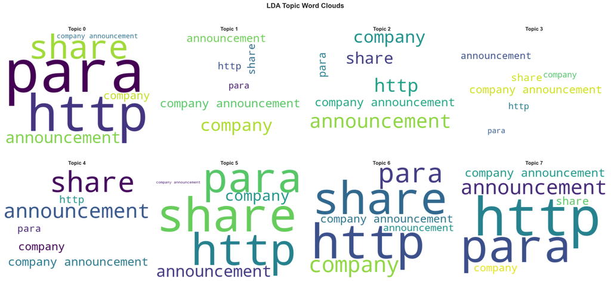

```
✓ Word clouds generated
```

```
✓ Time series visualization generated
```

```
✓ Topic-sentiment heatmap generated

✓ All visualizations complete
```

```python
# Comprehensive visualization suite
print("Generating visualizations...")

# 1. Topic Word Clouds
if WORDCLOUD_AVAILABLE:
    fig, axes = plt.subplots(2, 4, figsize=(20, 10))
    fig.suptitle('LDA Topic Word Clouds', fontsize=16, fontweight='bold')

    for topic_idx, words in enumerate(lda_topic_words):
        if topic_idx < 8:
            ax = axes[topic_idx // 4, topic_idx % 4]

            # Create word frequency dict
            word_freq = {word: (10 - i) for i, word in enumerate(words)}

            # Generate word cloud
            wc = WordCloud(
                width=400,
                height=300,
                background_color='white',
                colormap='viridis'
            ).generate_from_frequencies(word_freq)

            ax.imshow(wc, interpolation='bilinear')
            ax.set_title(f'Topic {topic_idx}', fontsize=12, fontweight='bold')
            ax.axis('off')

    plt.tight_layout()
    plt.show()
    print("✓ Word clouds generated")
else:
    print("WordCloud not available - skipping word cloud visualization")

# 2. Sentiment Time Series
news_data['date'] = pd.to_datetime(news_data['publish_date']).dt.date
daily_sentiment = news_data.groupby('date').agg({
    'sentiment_compound': ['mean', 'std', 'count']
}).reset_index()
daily_sentiment.columns = ['date', 'avg_sentiment', 'sentiment_std', 'article_count']

fig = make_subplots(
    rows=2, cols=1,
    subplot_titles=('Average Daily Sentiment', 'Article Volume'),
    vertical_spacing=0.12,
    specs=[[{"secondary_y": False}], [{"secondary_y": False}]]
)

# Sentiment trend
fig.add_trace(
    go.Scatter(
        x=daily_sentiment['date'],
        y=daily_sentiment['avg_sentiment'],
        mode='lines+markers',
        name='Avg Sentiment',
        line=dict(color='blue', width=2),
        marker=dict(size=6)
    ),
    row=1, col=1
)

# Article volume
fig.add_trace(
    go.Bar(
        x=daily_sentiment['date'],
        y=daily_sentiment['article_count'],
        name='Article Count',
        marker=dict(color='lightblue')
    ),
    row=2, col=1
)

fig.update_xaxes(title_text="Date", row=2, col=1)
fig.update_yaxes(title_text="Sentiment Score", row=1, col=1)
fig.update_yaxes(title_text="Article Count", row=2, col=1)

fig.update_layout(
    height=700,
    title_text="Media Sentiment and Volume Over Time",
    showlegend=True
)

fig.show()
print("✓ Time series visualization generated")

# 3. Topic-Sentiment Heatmap
topic_sentiment = news_data.groupby(['lda_topic', 'sentiment_label']).size().unstack(fill_value=0)

fig = px.imshow(
    topic_sentiment,
    labels=dict(x="Sentiment", y="Topic", color="Article Count"),
    x=topic_sentiment.columns,
    y=[f"Topic {i}" for i in topic_sentiment.index],
    color_continuous_scale='RdYlGn',
    title="Topic-Sentiment Distribution"
)

fig.update_layout(height=500)
fig.show()
print("✓ Topic-sentiment heatmap generated")

# 4. Geographic Choropleth (if clustering succeeded)
if GEO_CLUSTERING_SUCCESS:
    fig = px.scatter_geo(
        geo_data,
        lat='latitude',
        lon='longitude',
        color='geo_cluster',
        hover_data=['title', 'country', 'sentiment_label'],
        size_max=15,
        title='Geographic Distribution of News Coverage (Clustered)',
        color_continuous_scale='Viridis'
    )

    fig.update_geos(
        projection_type="natural earth",
        showcoastlines=True,
        coastlinecolor="Gray"
    )

    fig.update_layout(height=600)
    fig.show()
    print("✓ Geographic visualization generated")

print("\n✓ All visualizations complete")
```

## Key Findings and Interpretation

### Methodology Notes

- **LDA vs. BERTopic**: LDA provides interpretable bag-of-words topics, while BERTopic captures semantic context
- **VADER Limitations**: Works best for social media text; may need calibration for formal news
- **GDELT Coverage**: Biases toward English-language and Western media sources
- **Time Window**: Results are sensitive to the query period (7 days by default)

## Next Steps and Extensions

### Advanced Analysis

1. **Dynamic Topic Modeling**: Track how topics evolve over longer time periods (D35: News Mentions)
2. **Cross-Platform Comparison**: Compare GDELT news coverage with social media signals (D36: Social Media)
3. **Entity Recognition**: Extract and analyze named entities (people, organizations, locations)
4. **Network Analysis**: Build co-mention networks to identify topic relationships

### Integration Opportunities

- **Policy Analysis**: Combine with legislative tracking (D37: Legislative & Policy)
- **Economic Impact**: Correlate media sentiment with economic indicators (D01: Income & Poverty)
- **Public Health**: Track health-related narratives (D04: Health Outcomes)
- **Environmental Justice**: Monitor environmental coverage patterns (D12: Energy & Environment)

### Technical Improvements

- **Multilingual Analysis**: Extend to non-English news sources
- **Real-Time Monitoring**: Set up continuous ingestion pipeline
- **Anomaly Detection**: Identify unusual spikes in coverage or sentiment
- **Causal Analysis**: Investigate media framing effects on public opinion

### Related Notebooks

- **D35**: News Mentions & Trends (temporal dynamics)
- **D36**: Social Media Signals (Twitter/Reddit sentiment)
- **D37**: Legislative & Policy Analysis (policy tracking)
- **D39**: Cultural Sentiment & Reviews (consumer sentiment)

## References

### Data Sources

- Leetaru, K., & Schrodt, P. A. (2013). GDELT: Global data on events, location, and tone, 1979–2012. *ISA annual convention* (Vol. 2, No. 4, pp. 1-49).
- GDELT Project: https://www.gdeltproject.org/

### Methods

- Blei, D. M., Ng, A. Y., & Jordan, M. I. (2003). Latent dirichlet allocation. *Journal of machine Learning research*, 3(Jan), 993-1022.
- Grootendorst, M. (2022). BERTopic: Neural topic modeling with a class-based TF-IDF procedure. *arXiv preprint arXiv:2203.05794*.
- Hutto, C. J., & Gilbert, E. (2014). VADER: A parsimonious rule-based model for sentiment analysis of social media text. *Eighth international AAAI conference on weblogs and social media*.

### Software

- Bird, S., Klein, E., & Loper, E. (2009). *Natural language processing with Python*. O'Reilly Media.
- Pedregosa, F., et al. (2011). Scikit-learn: Machine learning in Python. *Journal of machine learning research*, 12(Oct), 2825-2830.

**End of Notebook**